# A Layered Grammar of Graphics

This is **Tutorial 5.1** from the ESL course taught at the Faculty of Informatics and Information Technologies, Slovak University of Technology in Bratislava.

The course loosely follows the book *An* *Introduction to Statistical Learning with Applications in R*[^1], while also drawing inspiration from Hadley Wickham’s *Advanced R*[^2]. You may notice small insights borrowed from these two excellent books here and there because they set a remarkably high standard for beginners, and they’re very hard to surpass.

| Version | Last Edit | Changes |
| --- | --- | --- |
| 2026.1 | 15-2-2026 | Minor text edits. |

This tutorial builds directly on the pre‑study material you’re expected to master by the end of week 2 and forms the foundation for the project you’ll tackle later. Study it carefully and complete all practice activities throughout weeks 3–6 to ensure you’re fully prepared.

### Motivation

The Grammar of Graphics provides a structured approach to data visualization, enabling the creation of complex and customized graphics through layered components. This framework simplifies the process of describing and constructing graphs, resulting in consistent and flexible visualizations.

In this tutorial, we will apply this framework to visualize football data from the FIFA dataset, allowing you to learn the intricacies of the process. In R, the Grammar of Graphics is implemented through the **ggplot2** package, created by Hadley Wickham. This powerful visualization tool allows users to create sophisticated and elegant graphics by defining plots with layers, scales, and themes.

### Exploring FIFA Data Through Visuals

Visualizing football data is key to understanding and communicating insights effectively. Transforming complex match statistics and player metrics into visual representations makes it easier to grasp, interpret, and derive actionable insights. By presenting data visually, coaches and analysts can quickly identify key performance indicators and make informed decisions on tactics and strategies. Visualizations can highlight crucial areas needing attention, aid in tactical planning, and drive success on the pitch. They also help uncover relationships and patterns that might be hidden within extensive data sets, and interactive visualizations allow deeper exploration of player and team performance.

In this tutorial, our objective is to explore the relationship between the overall and dribbling skills of FIFA players, considering their roles.

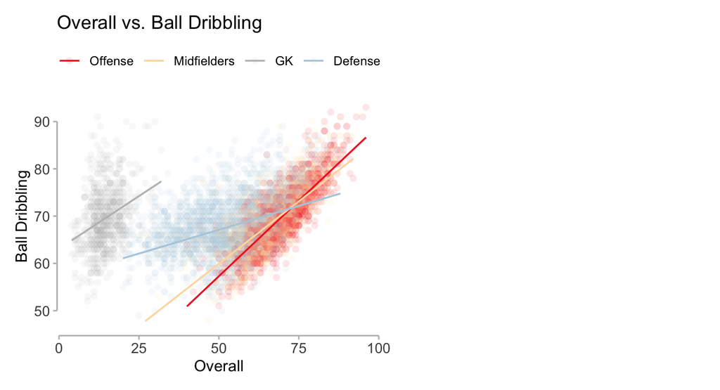

The `overall` score is a comprehensive measure of a player’s abilities and performance, calculated based on various attributes such as pace, shooting, passing, dribbling, defending, and physicality. This score provides a quick snapshot of a player’s skill level and is often used to compare players across different positions and teams. On the other hand, ball `dribbling` is a specialized `skill_` more frequently utilized by offensive players. Although it is plausible to argue that there is a strong relationship between these two scores, it may be more prominent in offensive players while less significant in others.

Are offensive players skilled more at ball dribbling? You probably already have an answer, but try to make your answer precise. What does the relationship between ball dribbling and the composite score look like? Is it positive? Negative? Linear? Nonlinear?

To examine this relationship, we can create a pair of plots for each player role, visualizing the roles of offense, defense, and midfielders. If our hypothesis is correct, we should observe distinct differences between these roles in the plots.

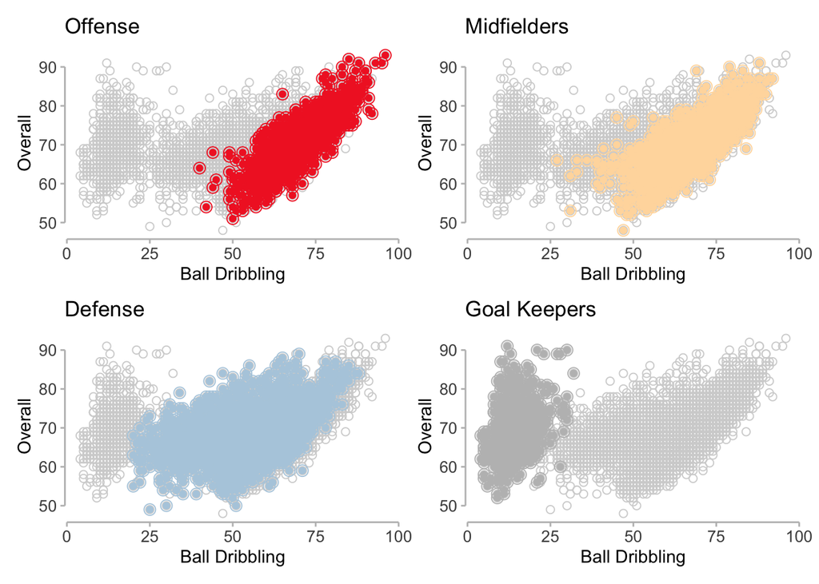

As you can see, ball dribbling skill is typically more crucial for offensive players, such as forwards and wingers, who need to maneuver past defenders and create scoring opportunities. Some, but not all, midfielders also benefit from strong dribbling abilities to maintain possession and transition the ball effectively between defense and attack.

Conversely, defensive players and goalkeepers rely less on dribbling skills, focusing more on tackling, positioning, and preventing the opposition from scoring. However, in some situations ball dribbling can be important for defenders as well, especially in modern football where defenders are required to play out from the back and maintain possession under pressure.

### Creating a Scatter Plot

Our ultimate goal is to recreate the first visualization displaying the relationship between `overall` score and `skill dribbling` of FIFA players, taking into consideration the `role` of the player.

R has several systems for making graphs, but ggplot2 is one of the most elegant and most versatile. We will start by creating a simple scatter plot and use that to introduce aesthetic mappings and geometric objects — the fundamental building blocks of grammar of graphics.

### Starting with an Empty Canvas

Using ggplot2, you start by creating a plot object with the `ggplot()` function, to which you can subsequently add various layers.

We assume you have loaded the `players_22.csv` file into R using the `read_csv()` function and performed data bucketing as demonstrated below. This gives us 7711 players to analyze.

```r
data %<>%
  mutate(role = case_when(str_detect(club_position, "^(CAM|CF|LAM|LF|LS|LW|RAM|RF|RS|RW|ST)$") ~ "Offense",
                          str_detect(club_position, "^(CDM|CM|LCM|LDM|LM|RCM|RDM|RM)$") ~ "Midfielders",
                          str_detect(club_position, "^(CB|LB|LCB|LWB|RB|RCB|RWB)$") ~ "Defense",
                          club_position == "GK" ~ "GK",
                          club_position == "RES" ~ "Reserve",
                          club_position == "SUB" ~ "Substitute",
                          TRUE ~ "Unknown")) %>%
  relocate(c(role, club_position), .after = player_positions) %>%
  filter(!(role %in% c("Unknown", "Reserve", "Substitute")))
```

The first argument of `ggplot()` is the dataset to use in the graph and so `ggplot(data = data)` creates an empty graph that is primed to display the FIFA data, but since we haven’t told it how to visualize it yet, for now it’s empty. This is not a very exciting plot, but you can think of it like an empty canvas you’ll paint the remaining layers of your plot onto.

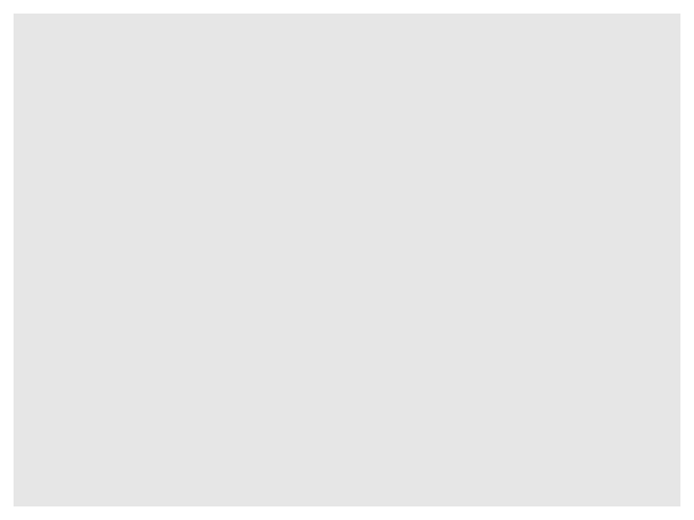

```r
ggplot(data = data)
```

Next, we need to tell `ggplot()` how the information from our data will be visually represented. The `mapping` argument of the `ggplot()` function defines how variables in your dataset are mapped to visual properties (**aesthetics**) of your plot. The **mapping** argument is always defined in the `aes()` function, and the `x` and `y` arguments of `aes()` specify which variables to map to the x and y axes.

For now, we will only map `skill_dribbling` to the `x` aesthetic and `overall` score to the `y` aesthetic. ggplot2 looks for the mapped variables in the `data` argument, in this case, the `players_22.csv` dataset structured as a tibble.

The following plot shows the result of adding these mappings.

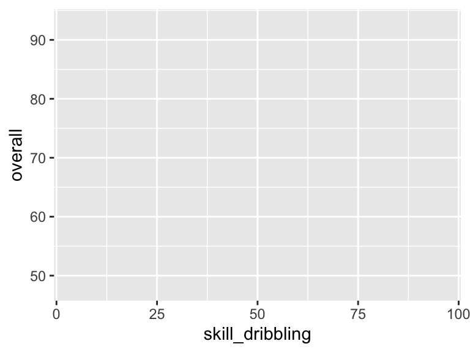

```r
ggplot(data = data,
       mapping = aes(x = skill_dribbling, y = overall))
```

Our empty canvas now has more structure – it’s clear where ball dribbling data will be displayed (on the x-axis) and where the overall score will be displayed (on the y-axis). But the players themselves are not yet on the plot. This is because we have not yet articulated how to represent the observations from our data frame on our plot.

### Adding Geoms

To do so, we need to define a **geom**: the geometrical object that a plot uses to represent data. These geometric objects are made available in ggplot2 with functions that start with `geom_`. People often describe plots by the type of geom that the plot uses.

For example, bar charts use bar geoms (`geom_bar()`), line charts use line geoms (`geom_line()`), boxplots use boxplot geoms (`geom_boxplot()`), scatterplots use point geoms (`geom_point()`), and so on.

The function `geom_point()` adds a layer of points to your plot, which creates a scatterplot. ggplot2 comes with many geom functions that each adds a different type of layer to a plot.

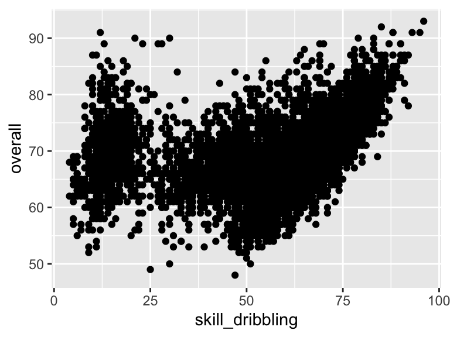

```r
ggplot(data = data,
       mapping = aes(x = skill_dribbling, y = overall)) +
  geom_point()
```

Now we have something that looks like what we might think of as a scatterplot. It doesn’t yet match our ultimate goal plot, but using this plot we can start answering the question that motivated our exploration: “What does the relationship between predictors and dependent variable look like?” The relationship appears to be positive. Players skilled at ball dribbling are generally better in terms of their overall performance, although this relationship is far from perfect.

### Tweaking Canvas Parameters

The scatterplot is not nice. We will therefore tweak its theme by starting with the `theme_bw()` (black and white theme) and adding further customization. We will remove major and minor grid lines, as well as the panel border, and add grey axis lines. This results in a clean and minimalist plot appearance.

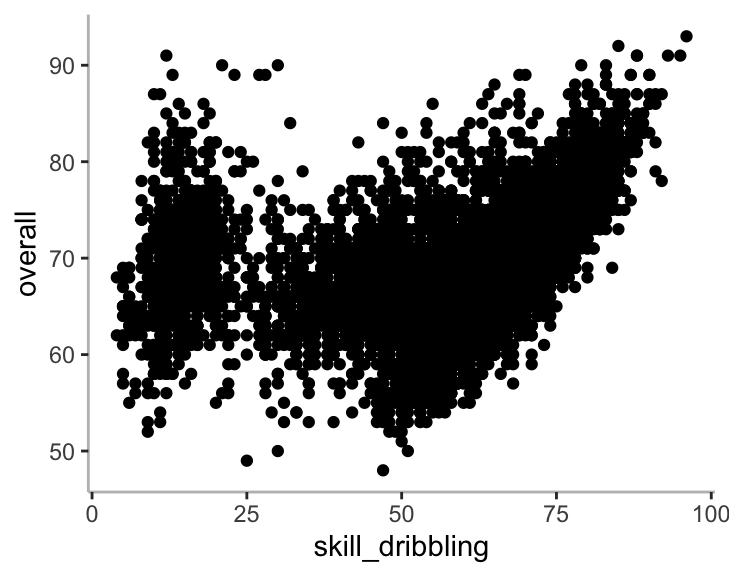

```r
# The plot defaults should be defined prior the ggplot2() function call
# and is applied to all subsequent plots unless explicitly reset.

theme_set(theme_bw() +
            theme(panel.grid.major = element_blank(),
                  panel.grid.minor = element_blank(),
                  panel.border = element_blank(),
                  axis.line = element_line(colour = "grey")))
```

### Adding Aesthetics

Scatter plots are useful for displaying the relationship between two numerical variables, but it’s always a good idea to be skeptical of any apparent relationship between two variables and ask if there may be other variables that explain or change the nature of this apparent relationship.

For example, does the relationship between overall and ball dribbling differ by player roles? Let’s incorporate roles into our plot and see if this reveals any additional insights into the apparent relationship between these variables. We will do this by representing player roles with different colored points.

To achieve this, will we need to modify the aesthetic or the geom? If you guessed “in the aesthetic mapping, inside of `aes()`”, you’re already getting the hang of creating data visualizations with ggplot2!

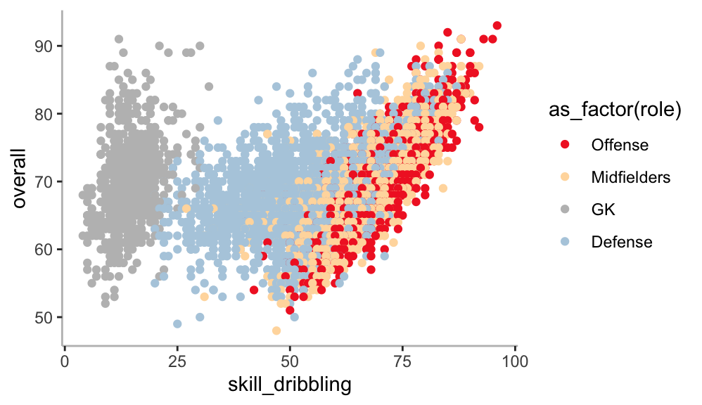

```r
ggplot(data = data,
       mapping = aes(x = skill_dribbling, y = overall, colour = as_factor(role))) +
  geom_point() +
  scale_color_manual(values = c("#f22a2a","#ffdbac", "grey", "#b3cde0"))
```

When a categorical variable is mapped to an aesthetic, ggplot2 will automatically assign a unique value of the aesthetic (here a unique color) to each unique level of the variable, a process known as **scaling**. ggplot2 will also add a legend that explains which values correspond to which levels.

Furthermore, scaling can be automatically managed using scale functions like `scale_color_manual()`, which adjust based on the number of unique values in your data. Given that the default color scheme in ggplot2 is often considered suboptimal, we will customize it to better suit our needs. By doing so, we can ensure that our visualizations are both aesthetically pleasing and effectively communicate the data’s insights.

### Tweaking Geom Visuals

When visualizing over 7000 players in a scatterplot, overplotting can obscure important patterns. To address this, you can adjust the geom parameters to differentiate points for various classes by using different shapes, sizes, or transparency levels, thereby reducing visual clutter. These parameters are specified as local settings within the geom function that represents the data — in this case, `geom_point()`.

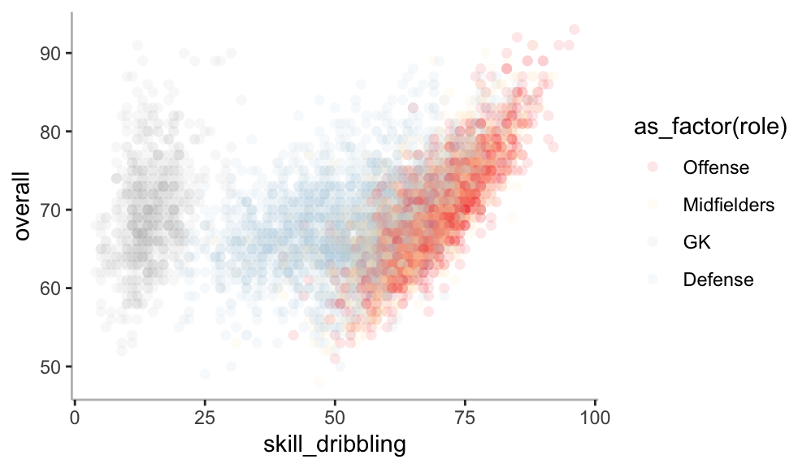

```r
ggplot(data = data,
       mapping = aes(x = skill_dribbling, y = overall, colour = as_factor(role))) +
  geom_point(shape = 16, alpha = 0.1, size = 2) +
  scale_color_manual(values = c("#f22a2a","#ffdbac", "grey", "#b3cde0"))
```

- **Size**: This parameter adjusts the size of points, lines, or other geoms, helping to emphasize certain data points or lines. For example, larger points can highlight specific observations in a scatter plot.
- **Shape**: This parameter determines the shape of points in scatter plots, with different shapes representing different categories or groups. This is useful for distinguishing between different types of data within the same plot.
- **Alpha**: This parameter controls the transparency of geoms, which is particularly useful for handling overplotting. By adjusting the alpha value, you can make overlapping points or lines more distinguishable, enhancing the clarity of your visualization.

### Tweaking Visuals of Axes

Tweaking plot visuals in ggplot2 can further enhance the clarity of your visualizations. By using the `theme()` function, you can adjust various elements such as axis text, panel borders, and axis lines.

In this case, setting `axis.text.x` and `axis.text.y` to `element_text(size = 10)` improves the readability of axis labels. Removing the panel border with `panel.border = element_blank()` and adding grey axis lines with `axis.line = element_line(colour = "grey")` creates a cleaner look. Additionally, customizing axis ticks with `axis.ticks = element_line(color = "grey")` ensures consistency in the plot’s appearance.

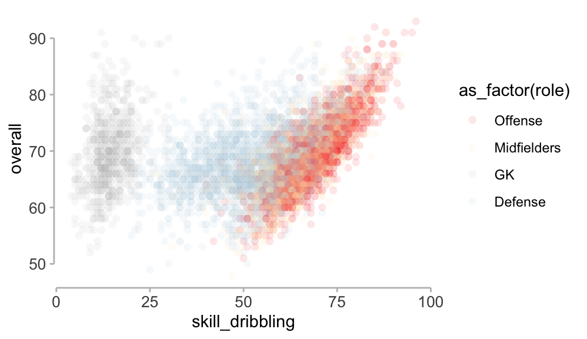

```r
ggplot(data = data,
       mapping = aes(x = skill_dribbling, y = overall, colour = as_factor(role))) +
  geom_point(shape = 16, alpha = 0.1, size = 2) +
  scale_color_manual(values = c("#f22a2a","#ffdbac", "grey", "#b3cde0")) +
  theme(axis.text.x = element_text(size = 10),
        axis.text.y = element_text(size = 10),
        panel.border = element_blank(),
        axis.line = element_line(colour = "grey"),
        axis.ticks = element_line(color = "grey")) +
  guides(x = guide_axis(cap = "both"),
         y = guide_axis(cap = "both"))
```

The `guides()` function allows further refinements of the plot by setting axis caps with `guide_axis(cap = "both")`, which helps in clearly defining the limits of the axes. These adjustments collectively contribute to a polished and professional-looking plot.

### Tweaking Plot Parameters

Finally, we can improve the labels of our plot using the `labs()` function in a new layer. Some of the arguments to `labs()` might be self explanatory: `title` adds a title and `subtitle` adds a subtitle to the plot. Other arguments match the aesthetic mappings for x and y-axis and the legend.

By setting `legend.position = "top"`, you move the legend to the top of the plot, which can make it more accessible and easier to interpret, especially in plots with multiple categories. Additionally, using `legend.title = element_blank()` removes the title from the legend.

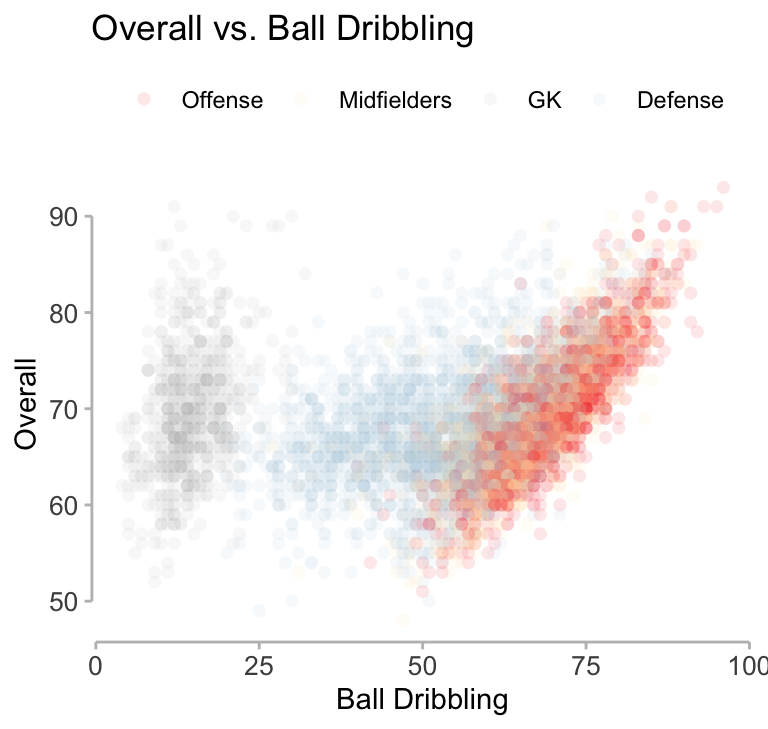

```r
ggplot(data = data,
       mapping = aes(x = skill_dribbling, y = overall, colour = as_factor(role))) +
  geom_point(shape = 16, alpha = 0.1, size = 2) +
  scale_color_manual(values = c("#f22a2a","#ffdbac", "grey", "#b3cde0")) +
  labs(title = "Overall vs. Ball Dribbling",
       x = "Ball Dribbling",
       y = "Overall",
       color = "Role", shape = "Role") +
  theme(legend.position="top",
        legend.title = element_blank(),
        axis.text.x = element_text(size = 10),
        axis.text.y = element_text(size = 10),
        panel.border = element_blank(),
        axis.line = element_line(colour = "grey"),
        axis.ticks = element_line(color = "grey")) +
  guides(x = guide_axis(cap = "both"),
         y = guide_axis(cap = "both"))
```

### Adding Layers

You can also enhance the scatterplot by adding a line that illustrates the relationship between ball dribbling skill and the overall score. This smooth curve will help us visualize trends and patterns more clearly. Since this is a new geometric object representing our data, we will add it as a new layer on top of our point geom by invoking the `geom_smooth()` function.

This function fits a smooth line to the data, making it easier to see the underlying relationship. By specifying the method as “`lm`” (linear model), we can draw a line of best fit, providing a clear visual representation of the correlation between the variables.

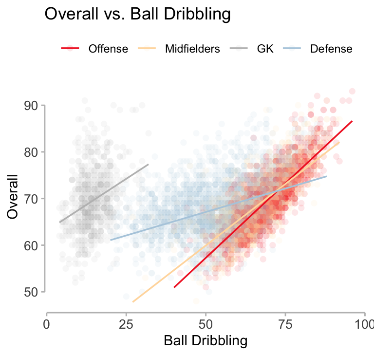

```r
ggplot(data = data,
       mapping = aes(x = skill_dribbling, y = overall, colour = as_factor(role))) +
  geom_point(shape = 16, alpha = 0.1, size = 2) +
  geom_smooth(method = "lm", se = FALSE, fill = NA, size = 0.6,
              aes(color = as_factor(role))) +
  scale_color_manual(values = c("#f22a2a","#ffdbac", "grey", "#b3cde0")) +
  labs(title = "Overall vs. Ball Dribbling",
       x = "Ball Dribbling",
       y = "Overall",
       color = "Role", shape = "Role") +
  theme(legend.position="top",
        legend.title = element_blank(),
        axis.text.x = element_text(size = 10),
        axis.text.y = element_text(size = 10),
        panel.border = element_blank(),
        axis.line = element_line(colour = "grey"),
        axis.ticks = element_line(color = "grey")) +
  guides(x = guide_axis(cap = "both"),
         y = guide_axis(cap = "both"))
```

### Function Calls

As we move on from these introductory sections, we’ll transition to a more concise expression of ggplot2 code. So far we’ve been very explicit, which is helpful when you are learning:

```r
ggplot(data = data,
       mapping = aes(x = skill_dribbling, y = overall)) +
  geom_point(shape = 16, alpha = 0.1, size = 2)
```

Typically, the first one or two arguments to a function are crucial and should be memorized. For `ggplot()`, these arguments are `data` and `mapping`. In the rest of these tutorials, we will omit these names to save typing and reduce extra text, making it easier to spot differences between plots. A more concise version of the previous plot is:

```r
ggplot(data,aes(x = skill_dribbling, y = overall)) +
  geom_point(shape = 16, alpha = 0.1, size = 2)
```

or with magrittr pipes[^3] the code can become even simpler.

```r
data %>%
  ggplot(aes(x = skill_dribbling, y = overall)) +
  geom_point(shape = 16, alpha = 0.1, size = 2)
```

### Wrapping Code into a Function

Finally, you have a plot that somewhat matches our goal! But this is not the end. Let’s dwell into how this code can be made more functional and modular.

Fine-tuning `ggplot2` code by writing custom functions is essential for creating reusable, efficient, and adaptable visualizations. Custom functions allow you to encapsulate repetitive code, making it easier to apply consistent styling and formatting across multiple plots. Additionally, using the `{{}}` (curly-curly) operator in custom functions enables dynamic and flexible mapping of variables, allowing you to create versatile plots that can handle different datasets and variable names seamlessly.

```r
create_plot <- function(data, x, y, color_factor, plot_title) {
  data %>%
    ggplot(aes(x = {{ x }}, y = {{ y }},
               colour = as_factor({{ color_factor }}),
               group = as_factor({{ color_factor }}))) +
    geom_point(shape = 16, alpha = 0.1, size = 2) +
    stat_smooth(method = "lm", se = TRUE, fill = NA, linewidth = 0.6,
                aes(colour = as_factor({{ color_factor }}))) +
    scale_color_manual(values = c("#f22a2a","#ffdbac", "grey", "#b3cde0" )) +
    labs(title = plot_title,
         x = "Overall",
         y = "Ball Dribbling") +
    scale_y_continuous(labels = scales::comma) +
    theme(legend.position="top",
          legend.title = element_blank(),
          axis.text.x = element_text(size = 10),
          axis.text.y = element_text(size = 10),
          panel.border = element_blank(),
          axis.line = element_line(colour = "grey"),
          axis.ticks = element_line(color = "grey")) +
    guides(x = guide_axis(cap = "both"),
           y = guide_axis(cap = "both"))
}

create_plot(data, skill_dribbling, overall, role, "Overall vs. Ball Dribbling")
```

In this example, `{{ x }}` and `{{ y }}` capture the expressions passed to the function, allowing `ggplot2` to evaluate them correctly within the plot. The `{{` operator can be substituted with the `!!` (bang-bang) operator in certain contexts, particularly when you want to unquote and evaluate an expression within a function. Here’s how you can achieve similar functionality with the `!!` operator and it is something you might encounter on the internet.

```r
library(rlang)

my_plot <- function(data, x, y) {
  x <- enquo(x)
  y <- enquo(y)
  ggplot(data, aes(!!x, !!y)) + geom_point()
}
```

### Making an Interactive Plot

ggplot2 is primarily designed for creating static, high-quality visualizations that are suitable for publication and reporting. Its focus is on providing a flexible and powerful grammar of graphics that allows users to build complex plots with detailed customization. However, this emphasis on static plots means that ggplot2 does not natively support interactivity.

To add interactivity to ggplot2 plots, you can use functions from the **plotly** package. First, create your **ggplot2** plot and save it as an object. Then, use the `ggplotly()` function from the plotly package to convert the static ggplot2 plot into an interactive plot:

```r
library(plotly)

plot.obj <- create_plot(data, skill_dribbling, overall, role, "Overall vs. Ball Dribbling")
ggplotly(plot.obj) # If you are running R Studio, ggplotly() will launch an interactive plot in the Viewer pane.
```

plotly enhances ggplot2 by converting static plots into interactive ones, allowing users to zoom, pan, and hover over data points to see additional information. This combination leverages the strengths of both packages: ggplot2 for its detailed customizable static plots, and plotly for its interactive capabilities.

### Arranging Plots into a Grid

Arranging plots in a grid is an effective way to compare different aspects of your data side by side. This technique is particularly useful when you want to highlight specific variables, such as player dribbling skills for different roles in a dataset; a relation that is shown on the following figure.

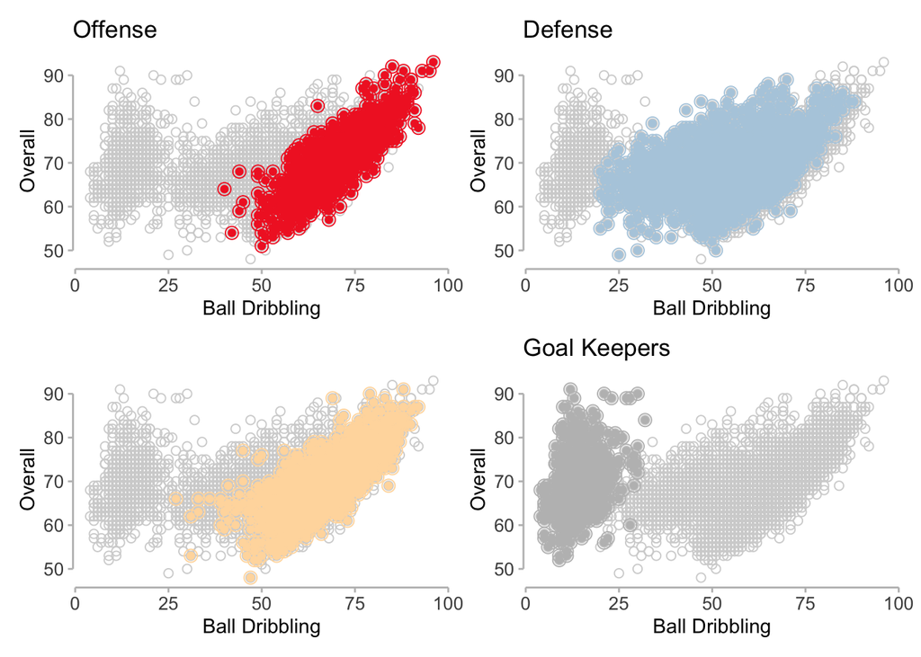

To recreate this figure, ggplot2 alone may not suffice, as its primary focus is on creating single plots and it has limited capabilities for arranging or splitting data into multiple visualizations. This is where the **patchwork** package comes in handy.

patchwork is designed to complement ggplot2 by enabling users to combine plots with a simple and flexible syntax. This process involves three key steps: wrapping ggplot code into a function, using that function to create a ggplot object for each scenario, and employing specific syntax to arrange these objects into a grid structure that will be plotted in R Studio. You can now follow the patchwork approach with the following code:

```r
#---- Step 1: Define scatter plot specifics. ----

create_plot <- function(data, x, y, color_factor, color, plot_title) {
  data %>%
    ggplot(aes(x = {{ x }}, y = {{ y }})) +
    geom_point(shape = 1, size = 2, colour = "lightgrey") +
    geom_point(data = data %>% filter(role == color_factor), shape = "circle open", size = 3, color = color) +
    geom_point(data = data %>% filter(role == color_factor), color = color) +
    labs(title = plot_title,
       subtitle =paste("Is ball dribbling important for", color_factor, "?"),
       x = "Ball Dribbling",
       y = "Overall") +
    theme(legend.position="top",
          legend.title = element_blank(),
          axis.text.x = element_text(size = 10),
          axis.text.y = element_text(size = 10),
          panel.border = element_blank(),
          axis.line = element_line(colour = "grey"),
          axis.ticks = element_line(color = "grey")) +
    guides(x = guide_axis(cap = "both"),
           y = guide_axis(cap = "both"))
}

#---- Step 2: Create and save ggplot objects for different scenarios. ----

offense.plot <- create_plot(data, skill_dribbling, overall, "Offense", "#f22a2a", "Overall vs. Ball Dribbling")
defense.plot <- create_plot(data, skill_dribbling, overall, "Defense", "#b3cde0", "")
midfielders.plot <- create_plot(data, skill_dribbling, overall, "Midfielders", "#ffdbac", "")
gk.plot <- create_plot(data, skill_dribbling, overall, "GK", "grey", "")

#---- Step 3: Arrange plots in a grid. ----

library(patchwork)

offense.plot + defense.plot + midfielders.plot + gk.plot +
  plot_layout(ncol = 2, nrow = 2) # Implemented by patchworks.
```

### Footnotes

[^1]: James, Gareth, Daniela Witten, Trevor Hastie, and Robert Tibshirani. 2021. *An Introduction to Statistical Learning: With Applications in R*. 2nd ed. New York: Springer.
[^2]: Wickham, Hadley. 2019. *Advanced R*. 2nd ed. Boca Raton, FL: CRC Press.
[^3]: You can use `%>%` for chaining data manipulation steps and creating a clear workflow, and use `%$%` when you need to expose variables within a data frame for direct use in a function. For ggplot2, `%>%` is more commonly used to streamline the process of data preparation and plotting.